# AA18.1: Découverte du tidyverse

# Visualiser avec `ggplot2`

`ggplot2` est une extension du *tidyverse* qui permet de générer des graphiques avec une syntaxe cohérente et puissante. Elle nécessite l’apprentissage d’un “mini-langage” supplémentaire, mais permet la construction de graphiques complexes de manière efficace.

Une des particularités de `ggplot2` est qu’elle part du principe que les données relatives à un graphique sont stockées dans un tableau de données (*data frame*, *tibble* ou autre).

## Préparation

`ggplot2` fait partie du coeur du *tidyverse*, elle est donc chargée automatiquement avec :

```r
library(tidyverse)
```

On peut également la charger explicitement avec :

```r
library(ggplot2)
```

Dans ce qui suit on utilisera le jeu de données des scories de culot (culot_blignicourt.csv) Le plus simple est de cliquer dessus puis choisir Ìmport dataset`

```r
library(readr)
co <- read_delim("culot_blignicourt.csv",
    ";", escape_double = FALSE, trim_ws = TRUE)
View(co)
```

## Initialisation

Un graphique `ggplot2` s’initialise à l’aide de la fonction `ggplot()`. Les données représentées graphiquement sont toujours issues d’un tableau de données (*data frame* ou *tibble*), qu’on passe en argument `data` à la fonction :

```r
ggplot(data = co)
## Ou, équivalent
ggplot(co)
```

On a défini la source de données, il faut maintenant ajouter des éléments de représentation graphique. Ces éléments sont appelés des `geom`, et on les ajoute à l’objet graphique de base avec l’opérateur `+`.

Un des `geom` les plus simples est `geom_histogram`. On peut l’ajouter de la manière suivante :

```r
ggplot(co) + geom_histogram()
```

Reste à indiquer quelle donnée nous voulons représenter sous forme d’histogramme. Cela se fait à l’aide d’arguments passés via la fonction `aes()`. Ici nous avons un paramètre à renseigner, `x`, qui indique la variable à représenter sur l’axe des x (l’axe horizontal). Par exemple :

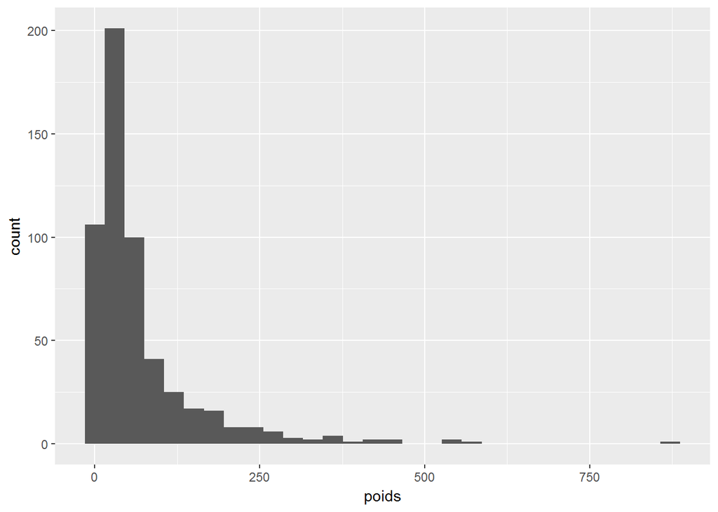

```r
ggplot(co) + geom_histogram(aes(x = poids))
```

Si on veut représenter une autre variable, il suffit de changer la valeur de `x` :

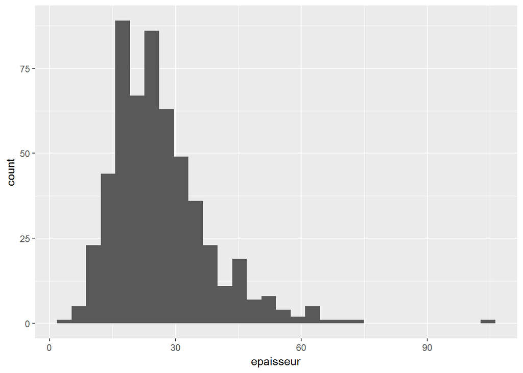

```r
ggplot(co) + geom_histogram(aes(x = epaisseur))
```

> Quand on spécifie une variable, inutile d’indiquer le nom du tableau de données sous la forme `co$epaisseur`, car `ggplot2` recherche automatiquement la variable dans le tableau de données indiqué avec le paramètre `data`. On peut donc se contenter de `epaisseur`.

cotains `geom` prennent plusieurs paramètres. Ainsi, si on veut représenter un nuage de points, on peut le faire en ajoutant un `geom_point`. On doit alors indiquer à la fois la position en `x` et en `y` de ces points, il faut donc passer ces deux arguments à `aes()` :

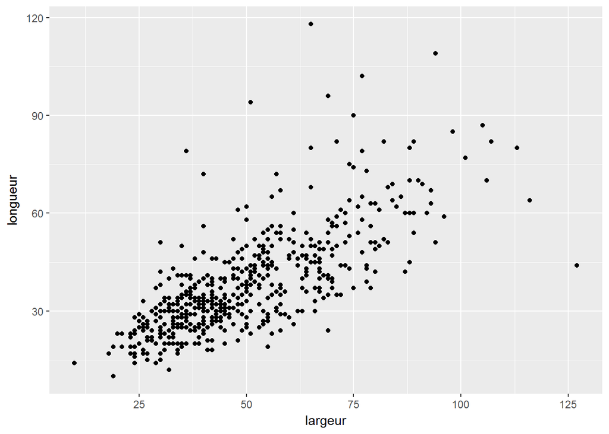

```r
ggplot(co) + geom_point(aes(x = largeur, y = longueur))
```

On peut modifier cotains attributs graphiques d’un `geom` en lui passant des arguments supplémentaires. Par exemple, pour un nuage de points, on peut modifier la couleur des points avec l’argument `color`, leur taille avec l’argument `size`, et leur transparence avec l’argument `alpha` :

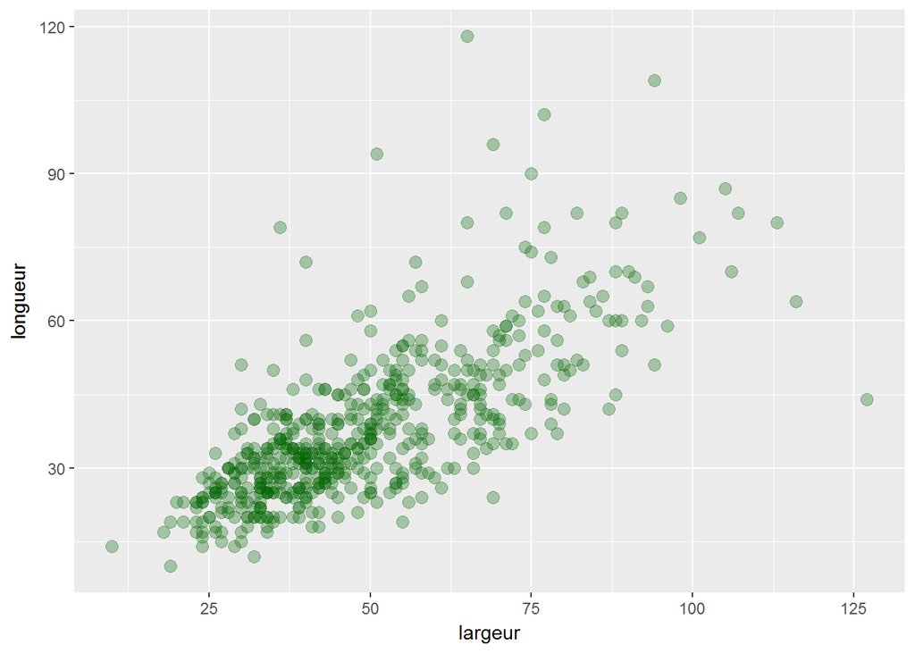

```r
ggplot(co) +
  geom_point(aes(x = largeur, y = longueur),
             color = "darkgreen", size = 3, alpha = 0.3)
```

## Exemples de `geom`

Il existe un grand nombre de `geom`, décrits en détail dans la [documentation officielle](http://ggplot2.tidyverse.org/reference/). Outre `geom_histogram` et `geom_point`, on pourra noter les `geom` suivants.

### `geom_boxplot`

`geom_boxplot` permet de représenter des boîtes à moustaches. On lui passe en `y` la variable dont on veut étudier la répartition, et en `x` la variable contenant les classes qu’on souhaite comparer. Ainsi, si on veut comparer la répartition des epaisseur en fonction de leur magnétisme, on pourra faire :

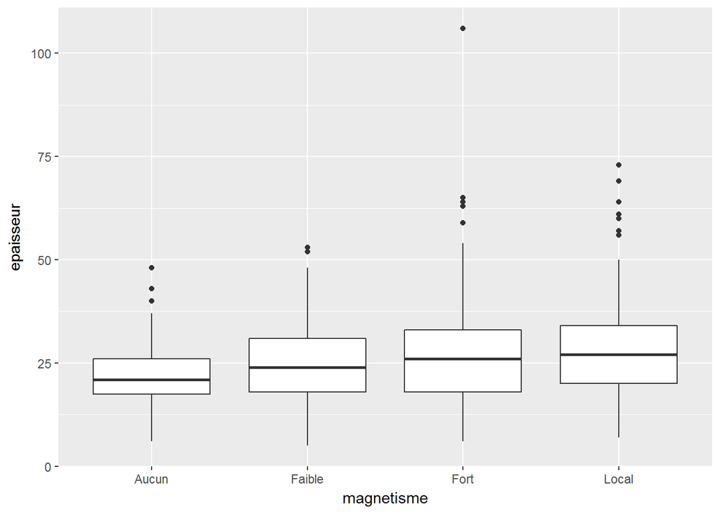

```r
ggplot(co) + geom_boxplot(aes(x = magnetisme, y = epaisseur))
```

À noter que dans ce cas, `x` doit être une variable qualitative, et `y` une variable numérique.

On peut personnaliser la présentation avec différents argument supplémentaires :

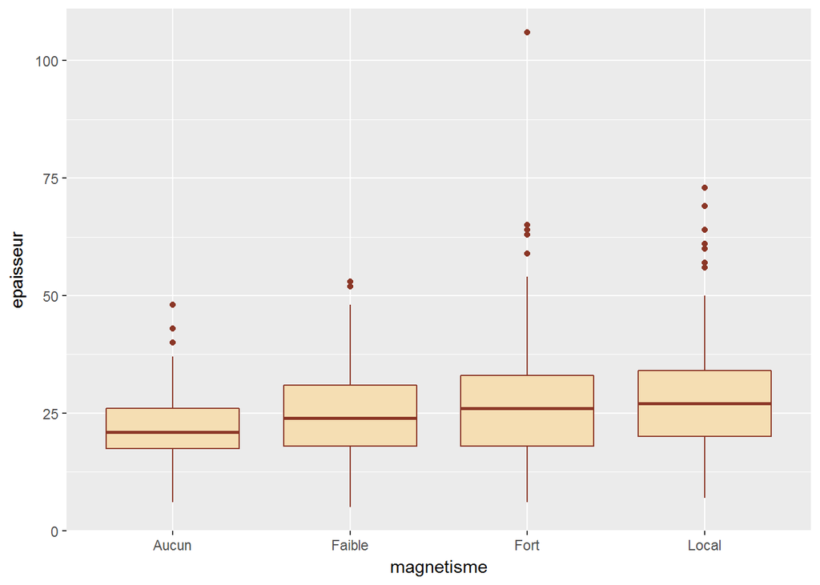

```r
ggplot(co) +
  geom_boxplot(aes(x = magnetisme, y = epaisseur), fill = "wheat", color = "tomato4")
```

Un autre argument utile, `varwidth`, permet de faire varier la largeur des boîtes en fonction des effectifs de la classe (donc, ici, en fonction du nombre de scories de chaque niveau de magnétisme) :

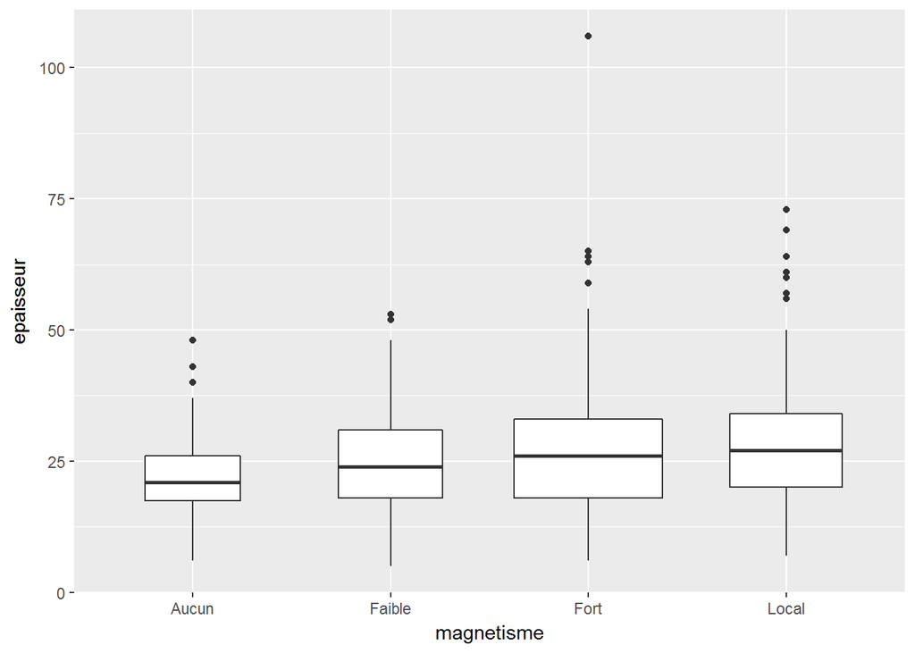

```r
ggplot(co) +
  geom_boxplot(aes(x = magnetisme, y = epaisseur), varwidth = TRUE)
```

### `geom_violin`

`geom_violin` est très semblable à `geom_boxplot`, mais utilise des graphes en violon à la place des boîtes à moustache.

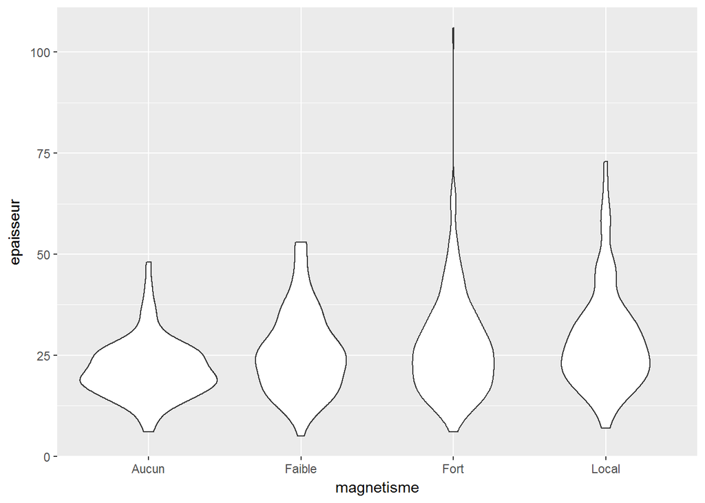

```r
ggplot(co) + geom_violin(aes(x = magnetisme, y = epaisseur))
```

Les graphes en violon peuvent donner une lecture plus fine des différences de distribution selon les classes.

### `geom_bar`

`geom_bar` permet de produire un graphique en bâtons (*bacolot*). On lui passe en `x` la variable qualitative dont on souhaite représenter l’effectif de chaque modalité.

Par exemple, si on veut afficher le nombre de scories de notre jeu de données pour chaque aspect :

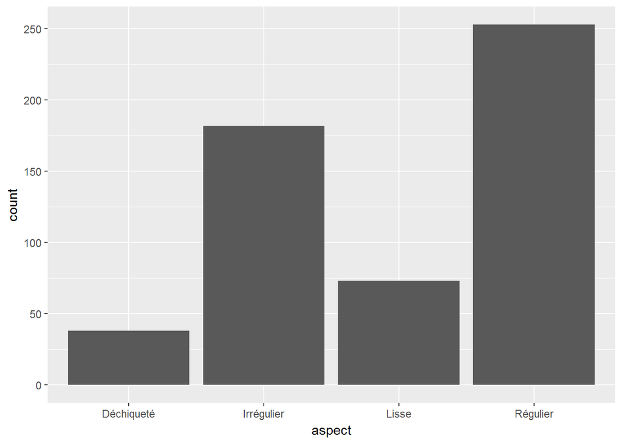

```r
ggplot(co) + geom_bar(aes(x = aspect))
```

Un cas assez fréquent mais un peu plus complexe survient quand on a déjà calculé le tri à plat de la variable à représenter. Dans ce cas on souhaite que `geom_bar` représente les effectifs sans les calculer : cela se fait en indiquant un mappage `y` pour la variable contenant les effectifs précalculés, et en ajoutant l’argument `stat = "identity"`.

Par exemple, si on a les données sous cette forme :

| aspect | n |
| --- | --- |
| Déchiqueté | 38 |
| Irrégulier | 182 |
| Lisse | 73 |
| Régulier | 253 |

On peut obtenir le graphique souhaité ainsi :

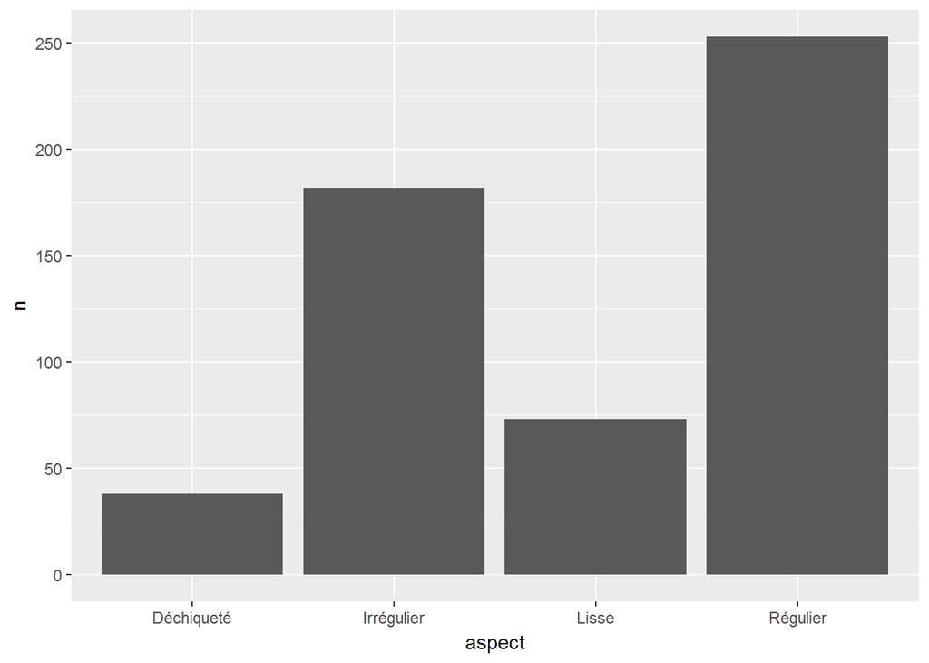

```r
ggplot(df) + geom_bar(aes(x = aspect, y = n), stat = "identity")
```

À noter qu’on peut aussi utiliser `geom_col` qui est un raccourci pour appliquer un `geom_bar` avec `stat = "identity"`. La commande précédente est donc équivalente à :

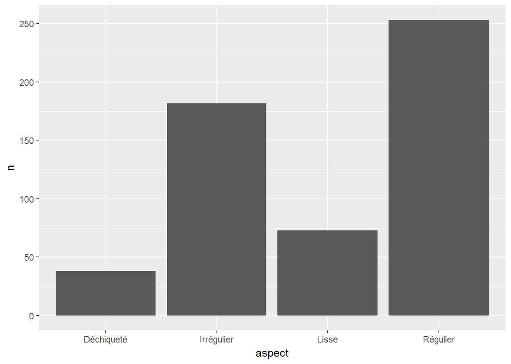

```r
ggplot(df) + geom_col(aes(x = aspect, y = n))
```

On peut également modifier l’apparence du graphique avec des arguments supplémentaires comme `fill` (remplissage) ou `width` (largeur/contour):

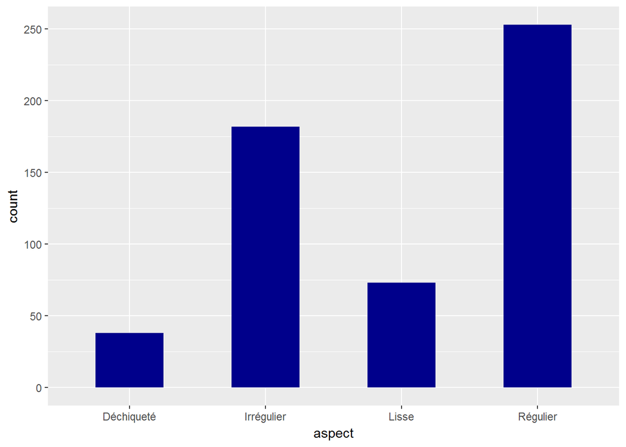

```r
ggplot(co) + geom_bar(aes(x = aspect), fill = "darkblue", width = .5)
```

### `geom_text`

`geom_text` représente des points identifiés par des labels. On doit lui passer `x` et `y` pour la position des points, et `label` pour le texte des étiquettes.

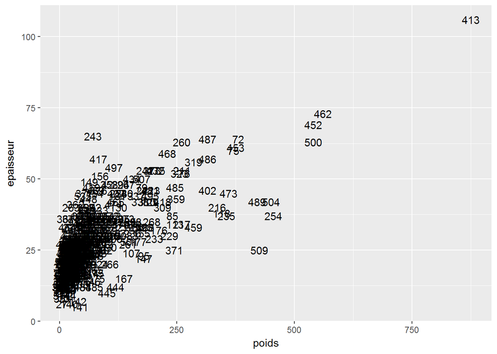

```r
ggplot(co) + geom_text(aes(x = poids, y = epaisseur, label = id))
```

On peut personnaliser l’apparence et la position du texte avec des arguments comme `size`, `color`, etc.

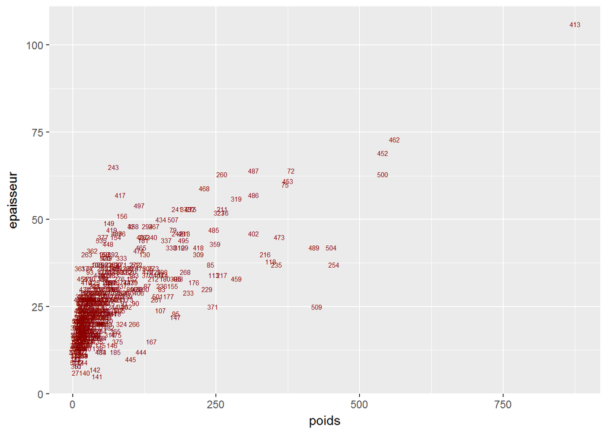

```r
ggplot(co) +
  geom_text(aes(x = poids, y = epaisseur, label = id), color = "darkred", size = 2)
```

### `geom_label`

`geom_label` est identique à `geom_text`, mais avec une présentation un peu différente.

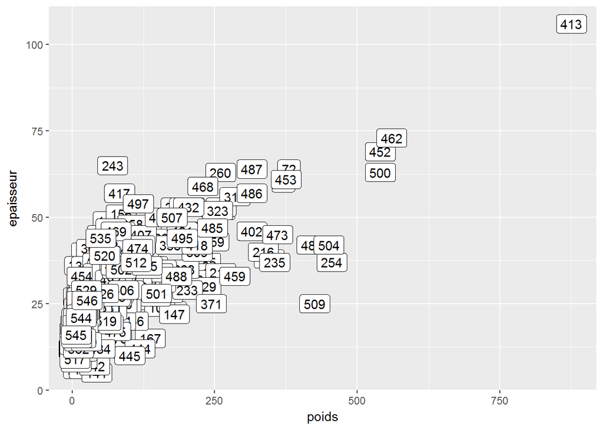

```r
ggplot(co) + geom_label(aes(x = poids, y = epaisseur, label = id))
```

### `geom_density`

`geom_density` permet d’afficher l’estimation de densité d’une variable numérique. Son usage est similaire à celui de `geom_histogram`.

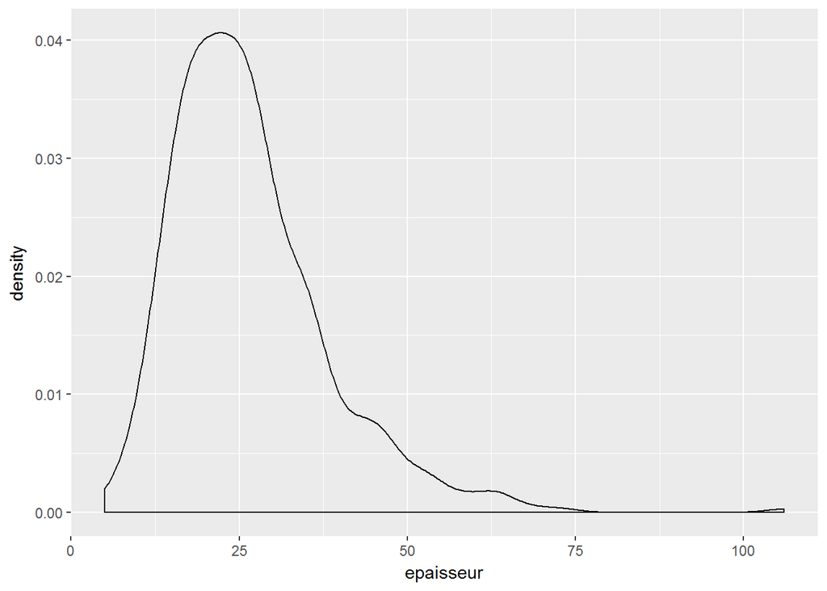

```r
ggplot(co) + geom_density(aes(x = epaisseur))
```

On peut utiliser différents arguments pour ajuster le calcul de l’estimation de densité, parmi lesquels `kernel` et `bw` (voir la page d’adide de la fonction `density` pour plus de détails) :

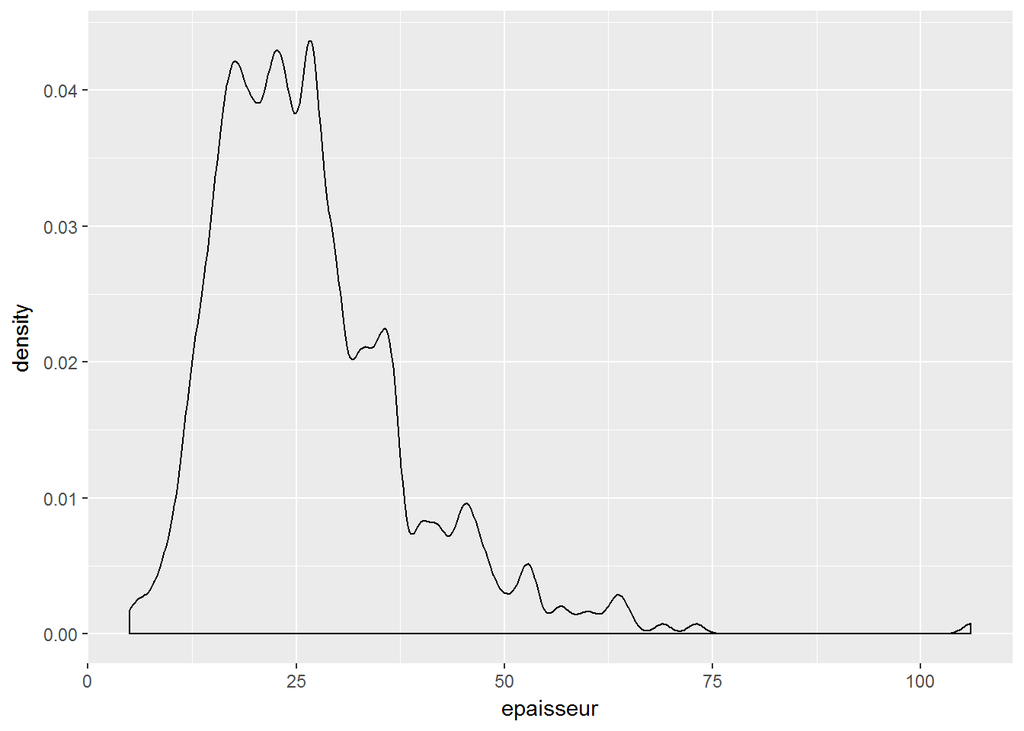

```r
ggplot(co) + geom_density(aes(x = epaisseur), bw = 1)
```

### `geom_line`

`geom_line` trace des lignes connectant les différentes observations entre elles. Il est notamment utilisé pour la représentation de séries temporelles. On passe à `geom_line` deux paramètres : `x` et `y`. Les observations sont alors connectées selon l’ordre des valeurs passées en `x`.

```r
data("economics")
economics
```

| date | pce | pop | psavert | uempmed | unemploy |
| --- | --- | --- | --- | --- | --- |
| 1967-07-01 | 507.4 | 198712 | 12.5 | 4.5 | 2944 |
| 1967-08-01 | 510.5 | 198911 | 12.5 | 4.7 | 2945 |
| 1967-09-01 | 516.3 | 199113 | 11.7 | 4.6 | 2958 |
| 1967-10-01 | 512.9 | 199311 | 12.5 | 4.9 | 3143 |
| 1967-11-01 | 518.1 | 199498 | 12.5 | 4.7 | 3066 |
| 1967-12-01 | 525.8 | 199657 | 12.1 | 4.8 | 3018 |
| 1968-01-01 | 531.5 | 199808 | 11.7 | 5.1 | 2878 |
| 1968-02-01 | 534.2 | 199920 | 12.2 | 4.5 | 3001 |
| 1968-03-01 | 544.9 | 200056 | 11.6 | 4.1 | 2877 |
| 1968-04-01 | 544.6 | 200208 | 12.2 | 4.6 | 2709 |

[output cut: 564 more lines]

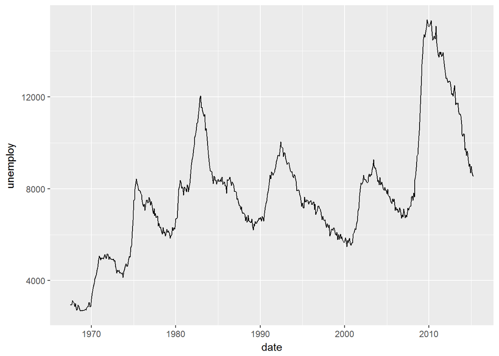

```r
ggplot(economics) + geom_line(aes(x = date, y = unemploy))
```

## Mappages

Un *mappage*, dans `ggplot2`, est une mise en relation entre **un attribut graphique** du `geom` (position, couleur, taille…) et **une variable** du tableau de données.

Ces mappages sont passés aux différents `geom` via la fonction `aes()` (abbréviation d’*aesthetic*).

### Exemples de mappages

On a déjà vu les mappages `x` et `y` pour un nuage de points. Ceux-ci signifient que la position d’un point donné horizontalement (`x`) et verticalement (`y`) depend de la valeur des variables passées comme arguments `x` et `y` dans `aes()` :

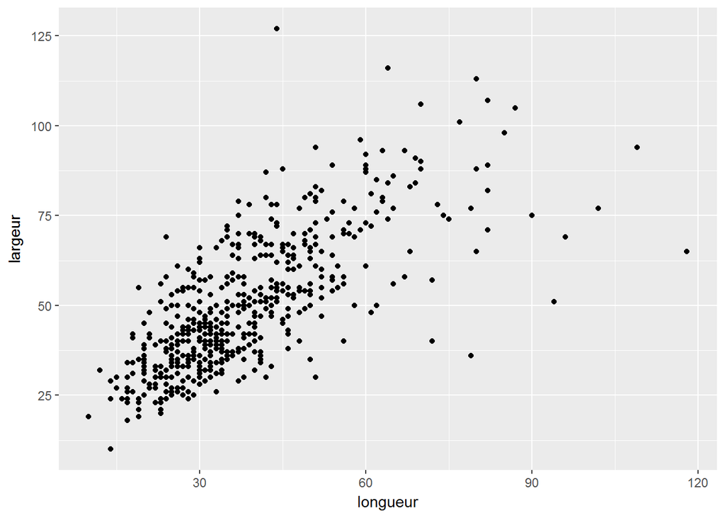

```r
ggplot(co) +
  geom_point(aes(x = longueur, y = largeur))
```

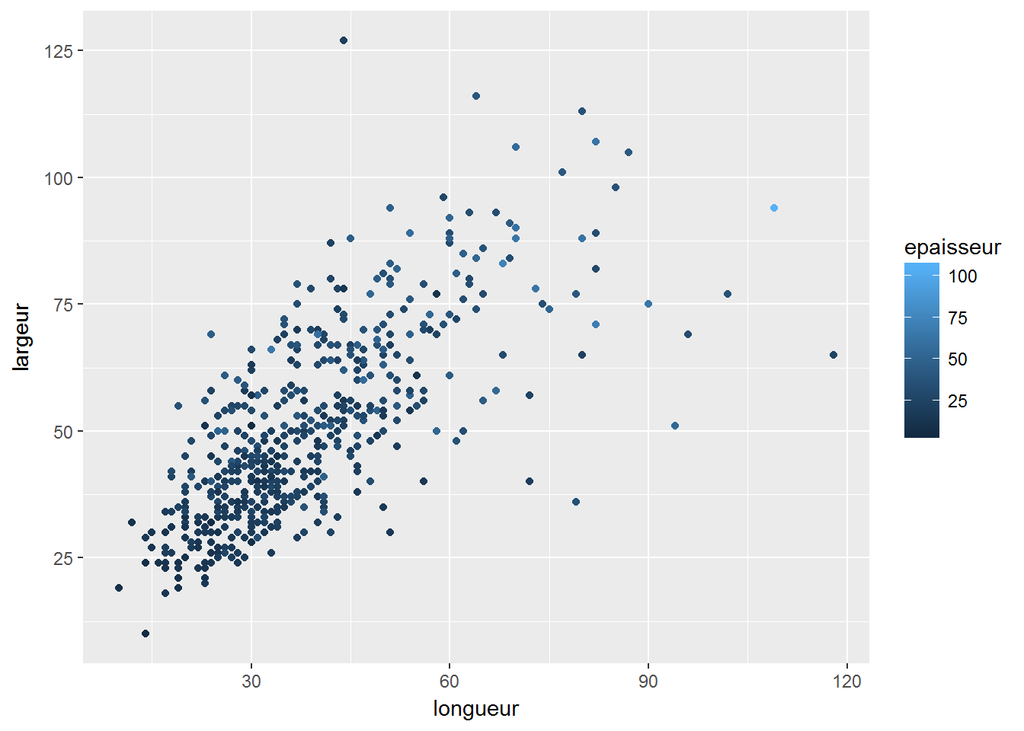

```r
ggplot(co) +
  geom_point(aes(x = longueur, y = largeur, color = epaisseur))
```

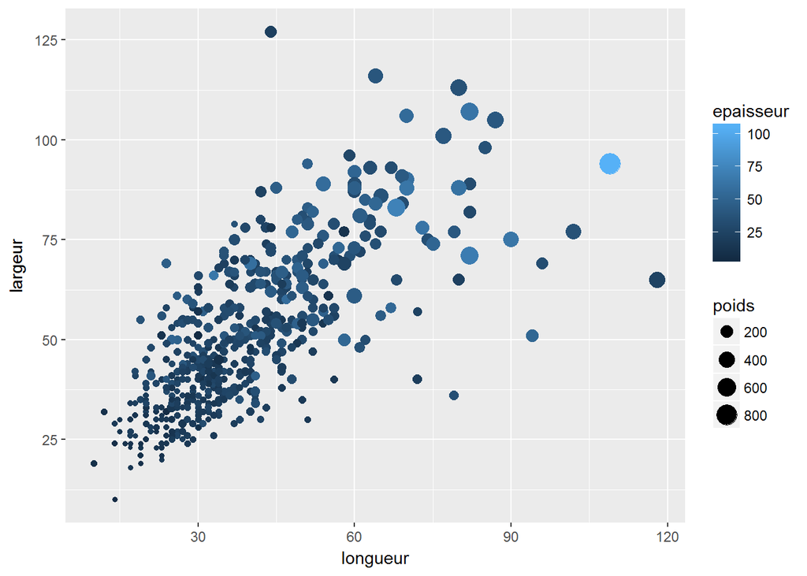

```r
ggplot(co) +
  geom_point(aes(x = longueur, y = largeur,
                 color = epaisseur, size = poids))
```

On peut même associer la transparence des points à une variable avec `alpha` :

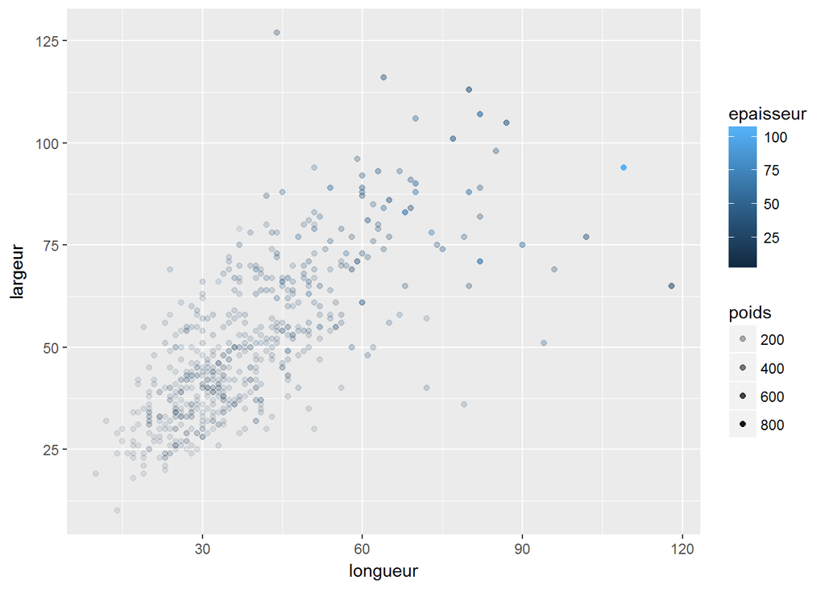

```r
ggplot(co) +
  geom_point(aes(x = longueur, y = largeur,
                 color = epaisseur, alpha = poids))
```

Chaque `geom` possède sa propre liste de mappages.

### `aes()` or not `aes()` ?

Comme on l’a déjà vu, parfois on souhaite changer un attribut sans le relier à une variable. Par exemple, on veut représenter tous les points en rouge. Dans ce cas on utilise toujours l’attribut `color`, mais comme il ne s’agit pas d’un mappage, on le définit **à l’extérieur** de la fonction `aes()` :

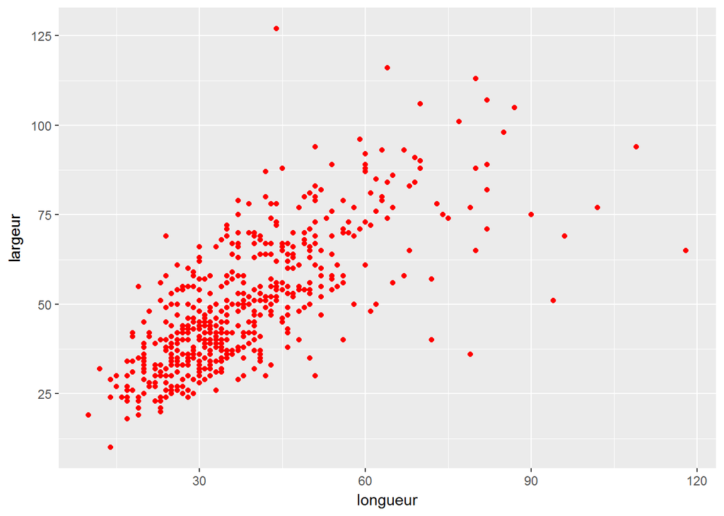

```r
ggplot(co) + geom_point(aes(x = longueur, y = largeur), color = "red")
```

Par contre, si on veut faire varier la couleur en fonction des valeurs prises par une variable, on réalise un mappage, et on doit donc placo l’attribut `color` **à l’intérieur** de `aes()`.

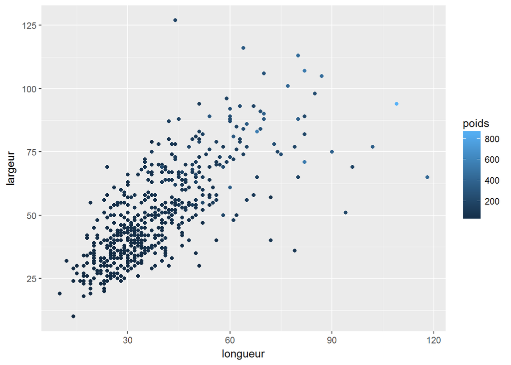

```r
ggplot(co) + geom_point(aes(x = longueur, y = largeur, color = poids))
```

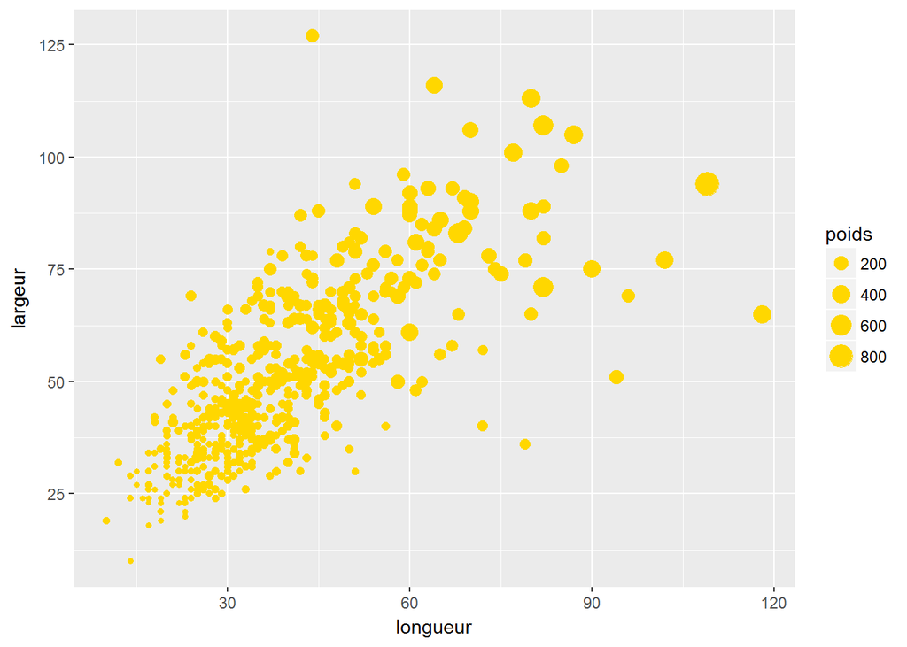

```r
ggplot(co) + geom_point(aes(x = longueur, y = largeur, size = poids), color = "gold")
```

Un des mappages possibles de `geom_bar` est l’attribut `fill`, qui permet de traco des barres de couleur différentes selon les modalités d’une variable :

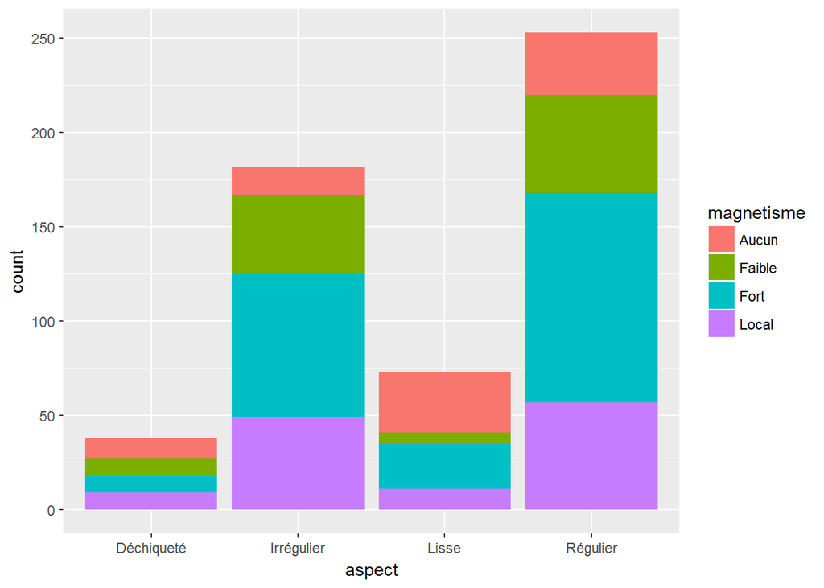

```r
ggplot(co) + geom_bar(aes(x = aspect, fill = magnetisme))
```

L’attribut `position` de `geom_bar` permet d’indiquer comment les différentes barres doivent être positionnées. Par défaut on a `position = "stack"` et elles sont donc “empilées”. Mais on peut préciser `position = "dodge"` pour les mettre côte à côte :

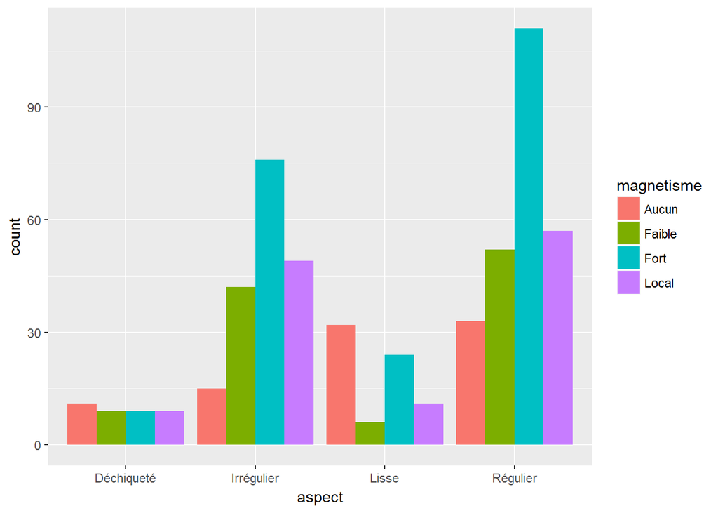

```r
ggplot(co) + geom_bar(aes(x = aspect, fill = magnetisme), position = "dodge")
```

Ou encore `position = "fill"` pour représenter non plus des effectifs, mais des proportions :

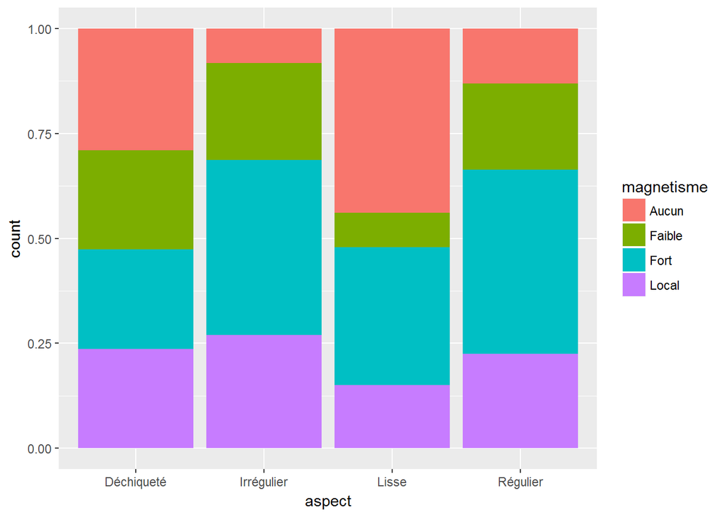

```r
ggplot(co) + geom_bar(aes(x = aspect, fill = magnetisme), position = "fill")
```